# Assignment3

Author

Yi Dou

## Exercise 03

```r
library(tidyverse)
crime_data <- read_csv("data/Crime_Incidents_in_2025.csv")
crime_data <- crime_data |>
  select(CCN, REPORT_DAT, START_DATE, END_DATE, BLOCK,
         OFFENSE, METHOD, SHIFT, LATITUDE, LONGITUDE)
crime_data |>
  glimpse()
```

```
Rows: 24,149
Columns: 10
$ CCN        <dbl> 25424649, 25172305, 25111532, 25043107, 25045981, 25047776,…
$ REPORT_DAT <chr> "2025/10/29 22:32:38+00", "2025/11/12 23:18:32+00", "2025/0…
$ START_DATE <chr> "2025/10/26 22:40:00+00", "2025/11/10 10:00:00+00", "2025/0…
$ END_DATE   <chr> "2025/10/27 00:00:00+00", "2025/11/10 21:00:00+00", "2025/0…
$ BLOCK      <chr> "444 - 499 BLOCK OF K STREET NW", "2237- 2399 BLOCK OF 33RD…
$ OFFENSE    <chr> "THEFT/OTHER", "THEFT F/AUTO", "THEFT/OTHER", "THEFT F/AUTO…
$ METHOD     <chr> "OTHERS", "OTHERS", "OTHERS", "OTHERS", "OTHERS", "OTHERS",…
$ SHIFT      <chr> "EVENING", "EVENING", "EVENING", "EVENING", "EVENING", "EVE…
$ LATITUDE   <dbl> 38.90252, 38.92168, 38.92901, 38.96309, 38.92158, 38.90644,…
$ LONGITUDE  <dbl> -77.01829, -76.96098, -77.05946, -77.06859, -76.99376, -77.…
```

This project uses administrative crime data from Washington, DC (District of Columbia Metropolitan Police Department (2025)). The time period represented by the data is from 2025-01-01 to 2026-01-01(UTC). The data were collected through administrative records from the Metropolitan Police Department based on reported crime incidents. Each observation represents a single reported crime incident and can be uniquely identified using the Crime Control Number (CCN). The data set is administrative and cross-sectional data including numeric, categorical, timeseries and geospatial variables. It does not include weights.

## Exercise 04

```r
sapply(crime_data, class)
```

```
        CCN  REPORT_DAT  START_DATE    END_DATE       BLOCK     OFFENSE
  "numeric" "character" "character" "character" "character" "character"
     METHOD       SHIFT    LATITUDE   LONGITUDE
"character" "character"   "numeric"   "numeric"
```

```r
crime_data <- crime_data |>
  mutate(
    report_datetime = ymd_hms(REPORT_DAT, tz = "UTC"),
    start_datetime  = ymd_hms(START_DATE,  tz = "UTC"),
    end_datetime    = ymd_hms(END_DATE,    tz = "UTC")
  )
str(crime_data$report_datetime)
```

```
 POSIXct[1:24149], format: "2025-10-29 22:32:38" "2025-11-12 23:18:32" "2025-07-23 23:13:42" ...
```

I examined the variable class of the data set. While other variables aligned with the data documentation, the three datetime variables were stored as strings. Luckily, they had all the information I needed, including date, time, and time zone. So I used the function in the lubridate package to transform them into datetime format.

## Exercise 05

```r
crime_data <- crime_data |>
  mutate(crime_duration = as.numeric(end_datetime - start_datetime, units = "hours"),
         reporting_delay = as.numeric(report_datetime - start_datetime, units = "hours"),
         month = month(start_datetime, label = TRUE, locale = "English"),
         quadrant = str_extract(BLOCK, "\\b(NE|NW|SE|SW)\\b"))
crime_data |>
  count(OFFENSE)
```

```
# A tibble: 9 × 2
  OFFENSE                        n
  <chr>                      <int>
1 ARSON                          4
2 ASSAULT W/DANGEROUS WEAPON   926
3 BURGLARY                     719
4 HOMICIDE                     127
5 MOTOR VEHICLE THEFT         3935
6 ROBBERY                     1323
7 SEX ABUSE                    101
8 THEFT F/AUTO                5367
9 THEFT/OTHER                11647
```

```r
crime_data |>
  count(METHOD)
```

```
# A tibble: 3 × 2
  METHOD     n
  <chr>  <int>
1 GUN     1293
2 KNIFE    391
3 OTHERS 22465
```

```r
crime_data |>
  group_by(month) |>
  summarise(monthly_crime_frequency = n())
```

```
# A tibble: 12 × 2
   month monthly_crime_frequency
   <ord>                   <int>
 1 Jan                      2009
 2 Feb                      1893
 3 Mar                      2073
 4 Apr                      2134
 5 May                      2307
 6 Jun                      2252
 7 Jul                      2334
 8 Aug                      2071
 9 Sep                      1901
10 Oct                      1739
11 Nov                      1737
12 Dec                      1699
```

```r
crime_data |>
  group_by(month) |>
  summarise(monthly_crime_frequency = n()) |>
  summarise(monthly_crime_frequency_mean = mean(monthly_crime_frequency),
            monthly_crime_frequency_median = median(monthly_crime_frequency),
            monthly_crime_frequency_max = max(monthly_crime_frequency),
            monthly_crime_frequency_min = min(monthly_crime_frequency))
```

```
# A tibble: 1 × 4
  monthly_crime_frequency_mean monthly_crime_frequency_…¹ monthly_crime_freque…²
                         <dbl>                      <dbl>                  <int>
1                        2012.                       2040                   2334
# ℹ abbreviated names: ¹monthly_crime_frequency_median,
#   ²monthly_crime_frequency_max
# ℹ 1 more variable: monthly_crime_frequency_min <int>
```

```r
crime_data |>
  count(SHIFT) |>
  mutate(proportion = n / sum(n)) |>
  select(SHIFT, proportion)
```

```
# A tibble: 3 × 2
  SHIFT    proportion
  <chr>         <dbl>
1 DAY           0.412
2 EVENING       0.416
3 MIDNIGHT      0.171
```

```r
crime_data |>
  summarise(crime_duration_mean = mean(crime_duration, na.rm = TRUE),
            crime_duration_sd = sd(crime_duration, na.rm = TRUE))
```

```
# A tibble: 1 × 2
  crime_duration_mean crime_duration_sd
                <dbl>             <dbl>
1                30.8              584.
```

```r
crime_data |>
  summarise(reporting_delay_mean = mean(reporting_delay, na.rm = TRUE),
            reporting_delay_sd = sd(reporting_delay, na.rm = TRUE))
```

```
# A tibble: 1 × 2
  reporting_delay_mean reporting_delay_sd
                 <dbl>              <dbl>
1                 119.              2621.
```

```r
crime_data |>
  group_by(quadrant) |>
  summarise(crime_duration_median = median(crime_duration, na.rm = TRUE),
            crime_duration_q75 = quantile(crime_duration, 0.75, na.rm = TRUE),
            reporting_delay_median = median(reporting_delay, na.rm = TRUE),
            reporting_delay_q75 = quantile(reporting_delay, 0.75, na.rm = TRUE))
```

```
# A tibble: 5 × 5
  quadrant crime_duration_median crime_duration_q75 reporting_delay_median
  <chr>                    <dbl>              <dbl>                  <dbl>
1 NE                       1                   4                      3.09
2 NW                       0.833               2.52                   3.41
3 SE                       1.15                3.13                   3.14
4 SW                       1.45                7                      6.53
5 <NA>                     1.1                 2.44                   3.20
# ℹ 1 more variable: reporting_delay_q75 <dbl>
```

Here I listed some summary statistics of this data set, including 8 different kinds of statistics(frequency, proportion, mean, median, max, min, sd and quantile) and 3 continuous variables(crime frequency, crime duration and reporting delay) based on 5 grouping variables(OFFENSE, METHOD, month, SHIFT and quadrant). I think these summary statistics are sufficient for understanding the univariate distributions in the data, as they show the concentration and dispersion of the key variable across different grouping variables.

## Exercise 06

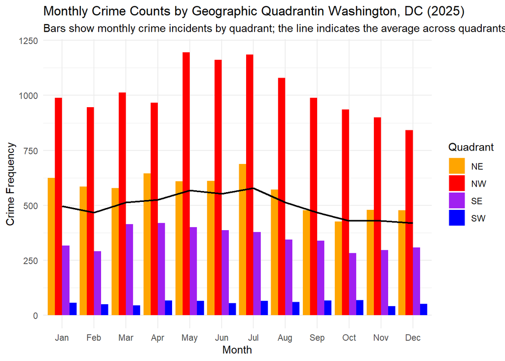

```r
monthly_counts <- crime_data |>
  filter(!is.na(quadrant)) |>
  count(quadrant, month)
monthly_mean <- monthly_counts |>
  group_by(month) |>
  summarise(quadrant_mean = mean(n))

ggplot(data = monthly_counts,
       mapping = aes(x = month, y = n, fill = quadrant)) +
  geom_col(position = "dodge") +
  geom_line(data = monthly_mean,
            aes(x = month, y = quadrant_mean, group = 1),
            inherit.aes = FALSE,
            color = "black",
            linewidth = 0.75) +
  scale_fill_manual(values = c(NE = "orange", NW = "red",
                               SE = "purple",  SW = "blue" )) +
  labs(x = "Month",
       y = "Crime Frequency",
       fill = "Quadrant",
       title = paste0("Monthly Crime Counts by Geographic Quadrant",
                      "in Washington, DC (2025)") ,
       subtitle = paste0("Bars show monthly crime incidents by quadrant; ",
                         "the line indicates the average across quadrants") ) +
  theme_minimal()
```

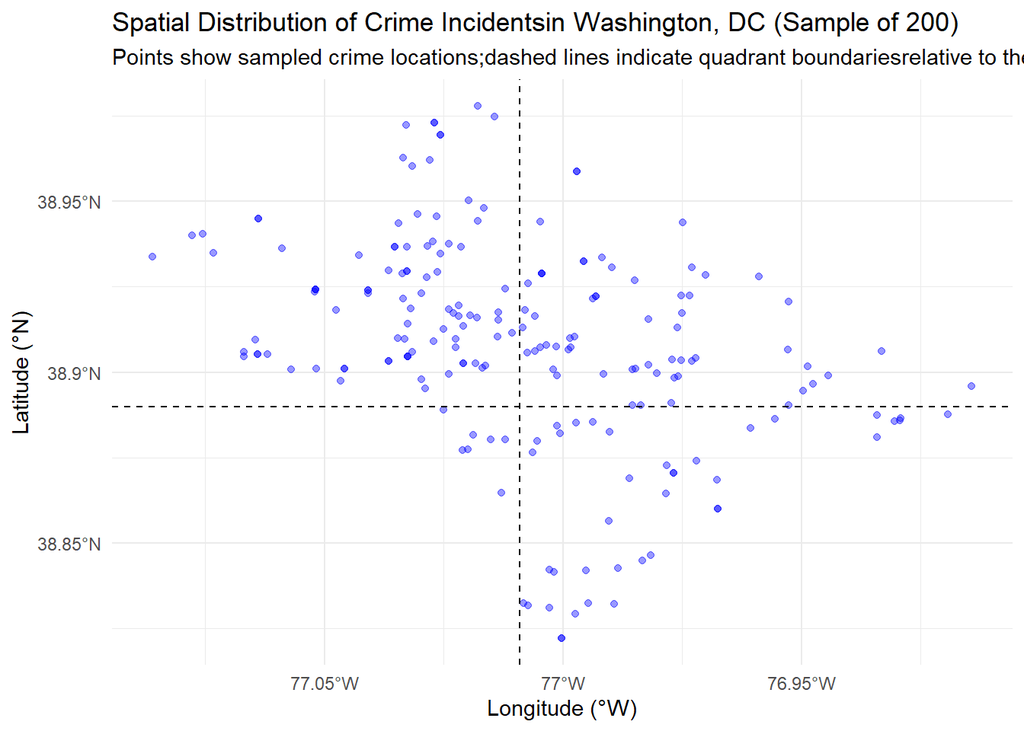

```r
crime_data |>
  slice_sample(n = 200) |>
  ggplot(aes(x = LONGITUDE, y = LATITUDE)) +
  geom_point(na.rm = TRUE, color = "blue", alpha = 0.4) +
  geom_vline(xintercept = -77.0091, linetype = "dashed", color = "black") +
  geom_hline(yintercept = 38.8899, linetype = "dashed", color = "black") +
  scale_x_continuous(
    name = "Longitude (°W)",
    labels = function(x) paste0(abs(round(x, 2)), "°W")
  ) +
  scale_y_continuous(
    name = "Latitude (°N)",
    labels = function(y) paste0(round(y, 2), "°N")
  ) +
  labs(title = paste0("Spatial Distribution of Crime Incidents",
                      "in Washington, DC (Sample of 200)"),
       subtitle = paste0("Points show sampled crime locations;",
                         "dashed lines indicate quadrant boundaries",
                         "relative to the U.S. Capitol")) +
  theme_minimal()
```

## Exercise 07

Here are some additional analysis I would perform on the data:

- Merging it with some data sets which contains demographic data of Washington, DC to understand the distribution of crimes more thoroughly
- Finding the determinants of reporting delay by running some machine learning models
- Creating some real geospatial visualizations which is more readable than the second figure based on the longitude and latitude data

## References

District of Columbia Metropolitan Police Department. 2025. “Crime Incidents in 2025.” DC Open Data. https://opendata.dc.gov/api/download/v1/items/74d924ddc3374e3b977e6f002478cb9b/csv?layers=7.